# Part II - (Students Performance Analysis)

## by Zaynab Mohammed

## Investigation Overview

> In this presentation, i intend to focus on the effect of parental level of education on students performance and also how important the type the students have affect their test scores.
> 1. Student with parents that have a high educational background performed better in the test than students with parents that have a lower educational background.
> 2. Students who had standard lunch scored higher averagely than students who had free/reduced lunch.
> 3. Students from ethnic group E performed better in the tests than students from any other ethnic group.

## Dataset Overview

> The Students Performance dataset originally contained 1000 rows and 8 variables (columns) consisting of both categorical and numerical variables. I created additional 2 columns which included the average score and total score of the students in the test. The dataset was sourced from kaggle.

Majority of the students that scored between 80-100%; the 'Top scorers' had Bachelor's degree holding parents, followed by master's degree and associate's degree. Parental level of education did have a significant influence on the students' performance in tests.

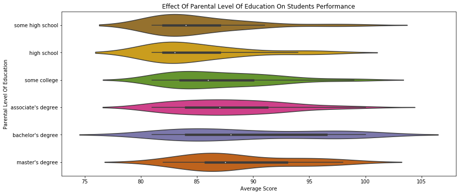

Studies have found that access to nutrition, particularly breakfast not only enhances students performance but can also enhance students psychosocial well-being, reduce aggression and school suspensions, and decrease discipline problems. This is infact true as shown in this data, students that had standard lunch performanced better overall in the tests than the students who had free/reduced lunch.

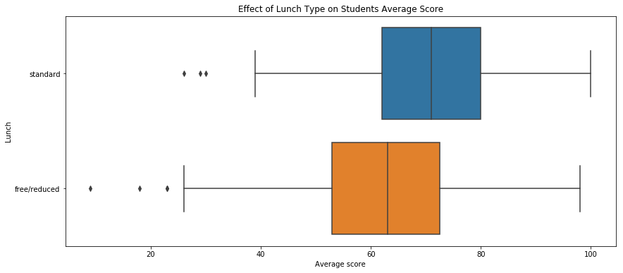

Parents of students from ethnic group E have the highest level of Educational background, having the highest rate of associate's degree, bachelor's degree and master's degree. And of course their wards had the highest performance in the test. This goes on to show the influnce of ethnicity on parental level of education and how that subsequently affects the students academic performance.

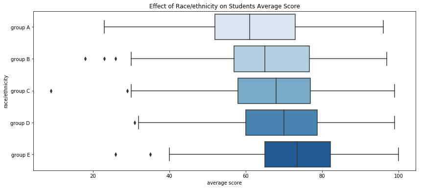